# MPDW 5

```r
library(ggplot2)
library(tsibble)
library(tseries)
library(MASS)
library(readxl)
data <- read_xlsx("C:\\Users\\Lusi Oktaviani\\OneDrive\\Statistics and Data Science\\Semester 5\\MPDW\\Praktikum\\Data.xlsx")
data
```

```
## # A tibble: 140 × 2
##    Periode Nilai
##      <dbl> <dbl>
##  1       1 48050
##  2       2 47950
##  3       3 47950
##  4       4 48560
##  5       5 46200
##  6       6 47020
##  7       7 46700
##  8       8 43060
##  9       9 47110
## 10      10 46200
## # ℹ 130 more rows
```

### Plot *Time Series*

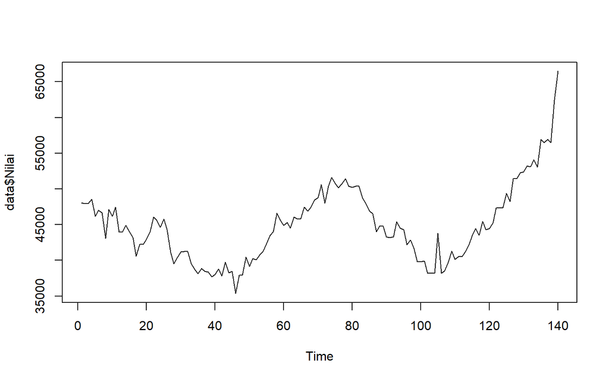

```r
ts.plot(data$Nilai)
```

Berdasarkan plot time series tersebut, terlihat bahwa data tidak stasioner dalam rataan dan ragam.

### Plot ACF

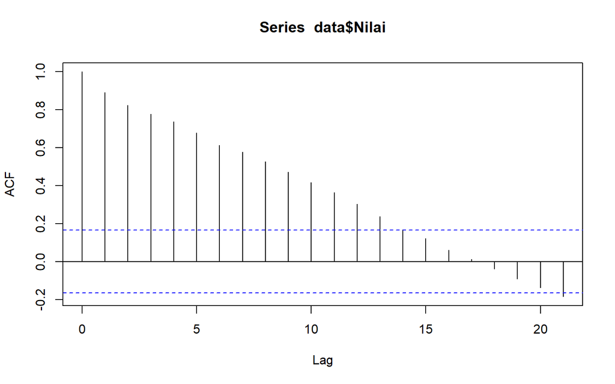

```r
acf(data$Nilai)
```

Berdasarkan plot ACF, terlihat bahwa plot ACF pada data tersebut cenderung *tails off* slowly dan membentuk gelombang sinus.

### Uji ADF

```r
adf.test(data$Nilai)
```

```
##
##  Augmented Dickey-Fuller Test
##
## data:  data$Nilai
## Dickey-Fuller = -0.20709, Lag order = 5, p-value = 0.99
## alternative hypothesis: stationary
```

$H_0$ : Data tidak stasioner dalam rataan

$H_1$ : Data stasioner dalam rataan

Berdasarkan uji ADF tersebut, didapat *p-value* sebesar 0.99 yang lebih besar dari taraf nyata 5% sehingga tak tolak $H_0$ dan menandakan bahwa data tidak stasioner dalam rataan. Hal ini sesuai dengan hasil eksplorasi menggunakan plot time series dan plot ACF.

### Plot Box-Cox

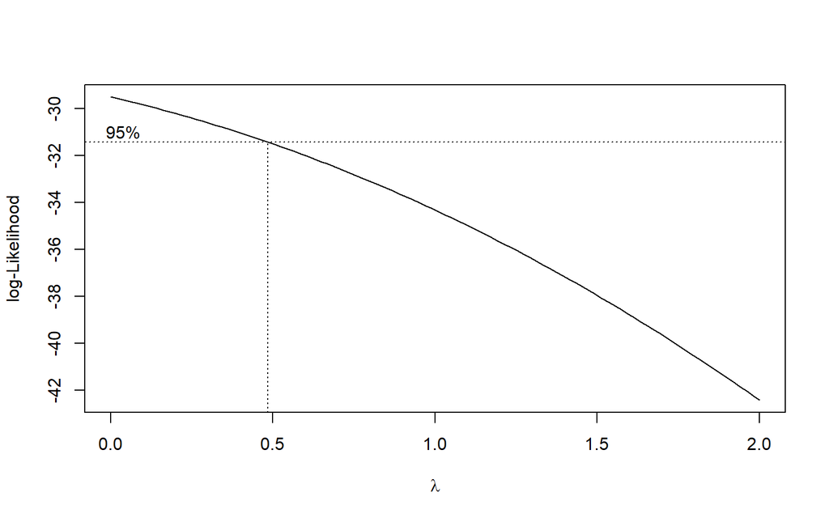

```r
index <- seq(1:140)
bc = boxcox(data$Nilai~index, lambda = seq(0,2,by=1))
```

```r
lambda <- bc$x[which.max(bc$y)]
lambda
```

```
## [1] 0
```

```r
#SK
bc$x[bc$y > max(bc$y) - 1/2 * qchisq(.95,1)]
```

```
##  [1] 0.00000000 0.02020202 0.04040404 0.06060606 0.08080808 0.10101010
##  [7] 0.12121212 0.14141414 0.16161616 0.18181818 0.20202020 0.22222222
## [13] 0.24242424 0.26262626 0.28282828 0.30303030 0.32323232 0.34343434
## [19] 0.36363636 0.38383838 0.40404040 0.42424242 0.44444444 0.46464646
```

Gambar di atas menunjukkan nilai *rounded value* ($\lambda$) optimum sebesar **0** pada selang kepercayaan 95% nilai memiliki batas bawah **0** dan batas atas **0.465**. Selang tersebut tidak memuat nilai satu sehingga dapat dikatakan bahwa data tidak stasioner dalam ragam.

### Partisi Data

#### Bagian 1

```r
# Bangkitkan data 70 periode pertama
data_70 <- data[1:70,]
data_70
```

```
## # A tibble: 70 × 2
##    Periode Nilai
##      <dbl> <dbl>
##  1       1 48050
##  2       2 47950
##  3       3 47950
##  4       4 48560
##  5       5 46200
##  6       6 47020
##  7       7 46700
##  8       8 43060
##  9       9 47110
## 10      10 46200
## # ℹ 60 more rows
```

#### Plot Time Series

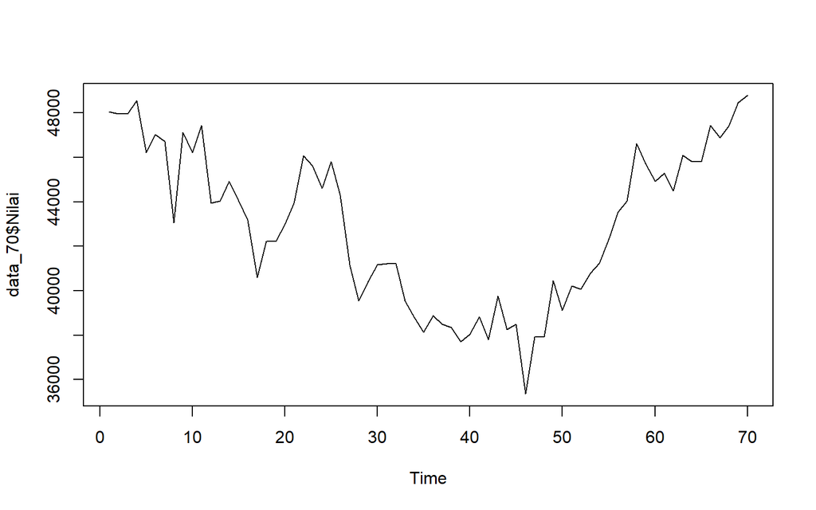

```r
ts.plot(data_70$Nilai)
```

Plot deret waktu di atas menunjukkan bahwa data tidak stasioner dalam rataan, dan tidak stasioner dalam ragam, ditandai dengan lebar pita yang cenderung tidak sama.

#### Plot ACF

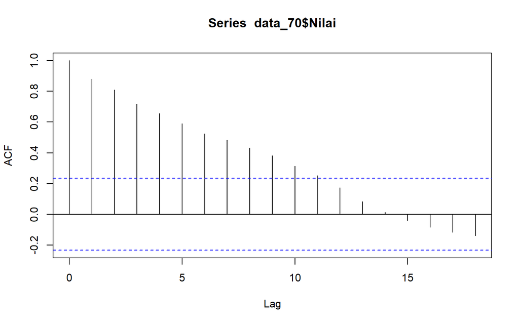

```r
acf(data_70$Nilai)
```

Berdasarkan hasil plot ACF tersebut, terlihat bahwa data tidak stasioner dalam rataan, ditandai dengan adanya nilai ACF yang tidak menurun secara eksponensial dan cenderung tails off slowly.

#### Uji ADF

```r
# Buat uji adf
adf.test(data_70$Nilai)
```

```
##
##  Augmented Dickey-Fuller Test
##
## data:  data_70$Nilai
## Dickey-Fuller = -0.52058, Lag order = 4, p-value = 0.9783
## alternative hypothesis: stationary
```

$H_0$ : Data tidak stasioner dalam rataan

$H_1$ : Data stasioner dalam rataan

#### Plot Boxcox

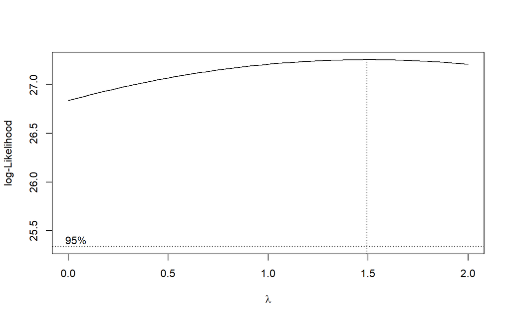

```r
index <- seq(1:70)
bc = boxcox(data_70$Nilai~index, lambda = seq(0,2,by=1))
```

```r
#Nilai Rounded Lambda
lambda <- bc$x[which.max(bc$y)]
lambda
```

```
## [1] 1.494949
```

```r
#SK
bc$x[bc$y > max(bc$y) - 1/2 * qchisq(.95,1)]
```

```
##   [1] 0.00000000 0.02020202 0.04040404 0.06060606 0.08080808 0.10101010
##   [7] 0.12121212 0.14141414 0.16161616 0.18181818 0.20202020 0.22222222
##  [13] 0.24242424 0.26262626 0.28282828 0.30303030 0.32323232 0.34343434
##  [19] 0.36363636 0.38383838 0.40404040 0.42424242 0.44444444 0.46464646
##  [25] 0.48484848 0.50505051 0.52525253 0.54545455 0.56565657 0.58585859
##  [31] 0.60606061 0.62626263 0.64646465 0.66666667 0.68686869 0.70707071
##  [37] 0.72727273 0.74747475 0.76767677 0.78787879 0.80808081 0.82828283
##  [43] 0.84848485 0.86868687 0.88888889 0.90909091 0.92929293 0.94949495
##  [49] 0.96969697 0.98989899 1.01010101 1.03030303 1.05050505 1.07070707
##  [55] 1.09090909 1.11111111 1.13131313 1.15151515 1.17171717 1.19191919
##  [61] 1.21212121 1.23232323 1.25252525 1.27272727 1.29292929 1.31313131
##  [67] 1.33333333 1.35353535 1.37373737 1.39393939 1.41414141 1.43434343
##  [73] 1.45454545 1.47474747 1.49494949 1.51515152 1.53535354 1.55555556
##  [79] 1.57575758 1.59595960 1.61616162 1.63636364 1.65656566 1.67676768
##  [85] 1.69696970 1.71717172 1.73737374 1.75757576 1.77777778 1.79797980
##  [91] 1.81818182 1.83838384 1.85858586 1.87878788 1.89898990 1.91919192
##  [97] 1.93939394 1.95959596 1.97979798 2.00000000
```

Gambar di atas menunjukkan nilai *rounded value* ($\lambda$) optimum sebesar **1.495** dan pada selang kepercayaan 95% nilai memiliki batas bawah **0** dan batas atas **2**. Selang tersebut memuat nilai satu sehingga dapat dikatakan bahwa data stasioner dalam ragam.

#### Bagian 2

```r
# Bangkitkan data 70 periode terakhir
data_70_2 <- data[71:140,]
data_70_2
```

```
## # A tibble: 70 × 2
##    Periode Nilai
##      <dbl> <dbl>
##  1      71 50630
##  2      72 48010
##  3      73 50370
##  4      74 51610
##  5      75 50800
##  6      76 50140
##  7      77 50720
##  8      78 51440
##  9      79 50370
## 10      80 50220
## # ℹ 60 more rows
```

#### Plot Time Series

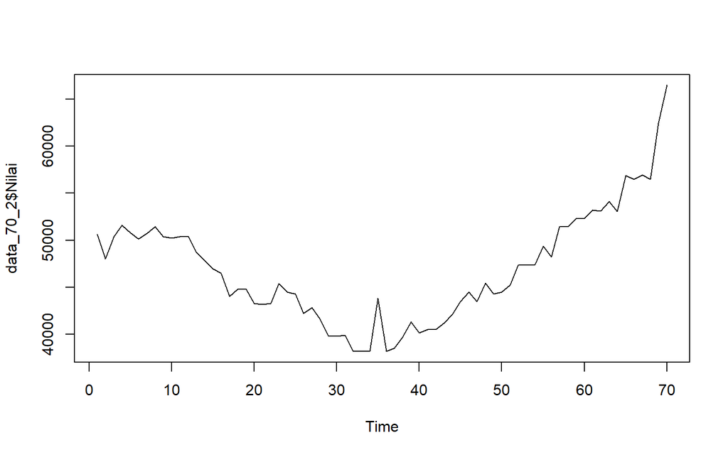

```r
ts.plot(data_70_2$Nilai)
```

Berdasarkan plot time series tersebut, terlihat bahwa data tidak stasioner dalam rataan dan terlihat dari lebar pita yang yang juga tidak sama menandakan data tidak stasioner dalam ragam.

#### Plot ACF

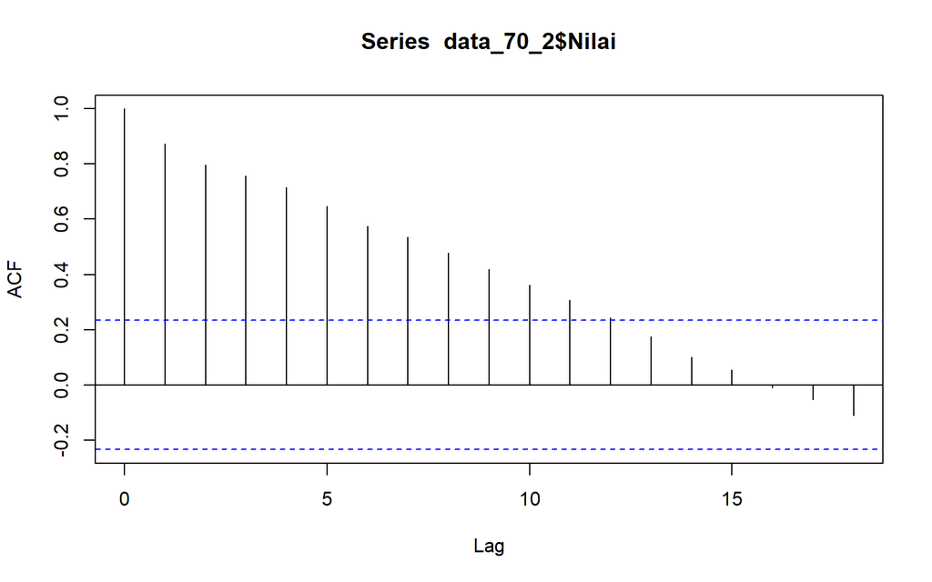

```r
# Buat plot ACF
acf(data_70_2$Nilai)
```

Berdasarkan hasil plot ACF tersebut, terlihat bahwa data tidak stasioner dalam rataan, ditandai dengan adanya nilai ACF yang tidak menurun secara eksponensial dan cenderung tails off slowly.

#### Uji ADF

```r
# Buat uji adf
adf.test(data_70_2$Nilai)
```

```
##
##  Augmented Dickey-Fuller Test
##
## data:  data_70_2$Nilai
## Dickey-Fuller = 0.99133, Lag order = 4, p-value = 0.99
## alternative hypothesis: stationary
```

$H_0$ : Data tidak stasioner dalam rataan

$H_1$ : Data stasioner dalam rataan

Berdasarkan uji ADF tersebut, didapat *p-value* sebesar 0.99 yang lebih besar dari taraf nyata 5% sehingga tak tolak $H_0$ dan menandakan bahwa data tidak stasioner dalam rataan. Hal ini sesuai dengan hasil eksplorasi menggunakan plot time series dan plot ACF.

#### Plot Boxcox

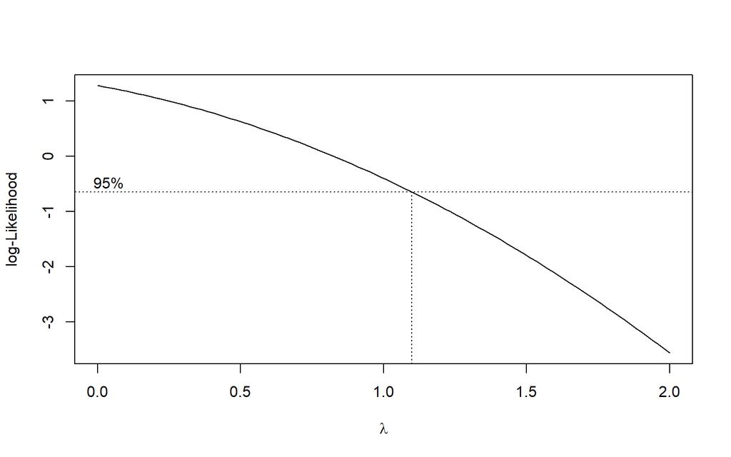

```r
index <- seq(71:140)
bc = boxcox(data_70_2$Nilai~index, lambda = seq(0,2,by=1))
```

```r
#Nilai Rounded Lambda
lambda <- bc$x[which.max(bc$y)]
lambda
```

```
## [1] 0
```

```r
#SK
bc$x[bc$y > max(bc$y) - 1/2 * qchisq(.95,1)]
```

```
##  [1] 0.00000000 0.02020202 0.04040404 0.06060606 0.08080808 0.10101010
##  [7] 0.12121212 0.14141414 0.16161616 0.18181818 0.20202020 0.22222222
## [13] 0.24242424 0.26262626 0.28282828 0.30303030 0.32323232 0.34343434
## [19] 0.36363636 0.38383838 0.40404040 0.42424242 0.44444444 0.46464646
## [25] 0.48484848 0.50505051 0.52525253 0.54545455 0.56565657 0.58585859
## [31] 0.60606061 0.62626263 0.64646465 0.66666667 0.68686869 0.70707071
## [37] 0.72727273 0.74747475 0.76767677 0.78787879 0.80808081 0.82828283
## [43] 0.84848485 0.86868687 0.88888889 0.90909091 0.92929293 0.94949495
## [49] 0.96969697 0.98989899 1.01010101 1.03030303 1.05050505 1.07070707
## [55] 1.09090909
```

Gambar di atas menunjukkan nilai *rounded value* ($\lambda$) optimum sebesar **0** dan pada selang kepercayaan 95% nilai memiliki batas bawah **0** dan batas atas **1.0909090**. Selang tersebut memuat nilai satu sehingga dapat dikatakan bahwa data bangkitan stasioner dalam ragam.